# Title:

Turning Retail Data into Business Growth: How Insights Drove Smarter Sales Decisions

# Introduction:

In today’s competitive retail market, many stores struggle to understand why certain products perform better than others. My retail sales analysis project aimed to bridge that gap — by transforming raw sales data into actionable business insights that could guide smarter decisions.

# Problem Statement:

The store was facing challenges with inconsistent sales performance across different product categories. Despite running promotions, results were unpredictable, and inventory imbalances led to overstock in some areas and shortages in others. Management needed clarity on what was truly driving sales trends and how to optimize their strategy.

# Dataset Description:

The dataset contained several months of transactional data, including:

Sales data: units sold, transaction date, and total revenue

This data provided a comprehensive view of both customer behavior and product performance.

# Steps of the Project:

Data Cleaning:

Exploratory Data Analysis (EDA):

Visualization:

Insight Generation:

Recommendations:

Adjust inventory planning to align with demand peaks

Redesign promotions based on data-backed insights rather than assumptions

[output not shown]

# Importation of DataSet

```python
import pandas as pd
```

```python
rsales = pd.read_csv(r"C:\Users\shadrach\Downloads\retail_sales_dataset 1.csv")
```

# Data Inspection

```python
rsales.head()
```

|  | Transaction ID | Date | Customer ID | Gender | Age | Product Category | Quantity | Price per Unit | Total Amount |
| --- | --- | --- | --- | --- | --- | --- | --- | --- | --- |
| 0 | 1 | 24/11/2023 | CUST001 | Male | 34 | Beauty | 3 | 50 | 150 |
| 1 | 2 | 27/02/2023 | CUST002 | Female | 26 | Clothing | 2 | 500 | 1000 |
| 2 | 3 | 13/01/2023 | CUST003 | Male | 50 | Electronics | 1 | 30 | 30 |
| 3 | 4 | 21/05/2023 | CUST004 | Male | 37 | Clothing | 1 | 500 | 500 |
| 4 | 5 | 06/05/2023 | CUST005 | Male | 30 | Beauty | 2 | 50 | 100 |

```python
rsales.shape
```

```
(1000, 9)
```

```python
rsales.columns
```

```
Index(['Transaction ID', 'Date', 'Customer ID', 'Gender', 'Age',
       'Product Category', 'Quantity', 'Price per Unit', 'Total Amount'],
      dtype='object')
```

```python
# rsales.info()
```

```python
rsales.describe()
```

|  | Transaction ID | Age | Quantity | Price per Unit | Total Amount |
| --- | --- | --- | --- | --- | --- |
| count | 1000.000000 | 1000.00000 | 1000.000000 | 1000.000000 | 1000.000000 |
| mean | 500.500000 | 41.39200 | 2.514000 | 179.890000 | 456.000000 |
| std | 288.819436 | 13.68143 | 1.132734 | 189.681356 | 559.997632 |
| min | 1.000000 | 18.00000 | 1.000000 | 25.000000 | 25.000000 |
| 25% | 250.750000 | 29.00000 | 1.000000 | 30.000000 | 60.000000 |
| 50% | 500.500000 | 42.00000 | 3.000000 | 50.000000 | 135.000000 |
| 75% | 750.250000 | 53.00000 | 4.000000 | 300.000000 | 900.000000 |
| max | 1000.000000 | 64.00000 | 4.000000 | 500.000000 | 2000.000000 |

# Data Cleaning

```python
rsales.isnull().sum()
```

```
Transaction ID      0
Date                0
Customer ID         0
Gender              0
Age                 0
Product Category    0
Quantity            0
Price per Unit      0
Total Amount        0
dtype: int64
```

```python
rsales.duplicated().sum()
```

```
0
```

```python
###since there is no duplicate ornull values in our data set, let chcek for unique enteri ngs in our data set
```

```python
rsales.nunique()
```

```
Transaction ID      1000
Date                 345
Customer ID         1000
Gender                 2
Age                   47
Product Category       3
Quantity               4
Price per Unit         5
Total Amount          18
dtype: int64
```

```python
###let chcek each if any has a mistake or a false unique
```

```python
rsales['Date'].unique()
```

```
array(['24/11/2023', '27/02/2023', '13/01/2023', '21/05/2023',
       '06/05/2023', '25/04/2023', '13/03/2023', '22/02/2023',
       '13/12/2023', '07/10/2023', '14/02/2023', '30/10/2023',
       '05/08/2023', '17/01/2023', '16/01/2023', '17/02/2023',
       '22/04/2023', '30/04/2023', '16/09/2023', '05/11/2023',
       '14/01/2023', '15/10/2023', '12/04/2023', '29/11/2023',
       '26/12/2023', '03/08/2023', '23/04/2023', '18/08/2023',
       '29/10/2023', '23/05/2023', '04/01/2023', '23/03/2023',
       '24/12/2023', '24/06/2023', '21/03/2023', '21/04/2023',
       '22/06/2023', '14/07/2023', '19/02/2023', '03/07/2023',
       '26/06/2023', '06/11/2023', '16/05/2023', '23/01/2023',
       '24/08/2023', '02/10/2023', '05/03/2023', '13/07/2023',
       '10/02/2023', '10/10/2023', '31/05/2023', '18/11/2023',
       '13/11/2023', '05/07/2023', '23/10/2023', '09/04/2023',
       '27/12/2023', '05/02/2023', '24/01/2023', '05/12/2023',
       '27/04/2023', '29/05/2023', '21/02/2023', '21/08/2023',
       '22/11/2023', '06/07/2023', '25/03/2023', '09/07/2023',
       '01/07/2023', '18/04/2023', '10/12/2023', '17/05/2023',
       '16/12/2023', '28/11/2023', '06/02/2023', '08/11/2023',
       '29/03/2023', '01/10/2023', '25/08/2023', '19/05/2023',
       '19/12/2023', '13/10/2023', '17/12/2023', '16/06/2023',
       '29/01/2023', '28/04/2023', '11/06/2023', '25/07/2023',
       '18/05/2023', '03/02/2023', '19/04/2023', '18/10/2023',
       '02/12/2023', '13/09/2023', '22/07/2023', '26/11/2023',
       '23/08/2023', '15/03/2023', '07/05/2023', '03/10/2023',
       '15/05/2023', '27/10/2023', '08/08/2023', '26/10/2023',
       '24/07/2023', '12/03/2023', '18/09/2023', '10/09/2023',
       '16/02/2023', '25/01/2023', '26/02/2023', '20/03/2023',
       '15/12/2023', '02/11/2023', '02/02/2023', '17/07/2023',
       '15/07/2023', '28/08/2023', '28/09/2023', '09/05/2023',
       '11/10/2023', '06/01/2023', '28/02/2023', '25/11/2023',
       '11/08/2023', '22/03/2023', '02/01/2023', '14/09/2023',
       '02/04/2023', '17/09/2023', '24/02/2023', '17/11/2023',
       '02/06/2023', '11/07/2023', '24/03/2023', '04/10/2023',
       '29/09/2023', '01/01/2023', '03/11/2023', '15/06/2023',
       '08/09/2023', '10/01/2023', '07/06/2023', '03/05/2023',
       '30/01/2023', '04/05/2023', '13/02/2023', '06/09/2023',
       '30/09/2023', '06/03/2023', '07/03/2023', '04/12/2023',
       '01/09/2023', '09/10/2023', '26/03/2023', '07/11/2023',
       '20/12/2023', '13/04/2023', '01/01/2024', '09/06/2023',
```

[output cut: 32 more lines]

```
       '21/06/2023', '09/11/2023', '22/08/2023', '01/08/2023',
       '19/11/2023', '22/10/2023', '10/04/2023', '16/07/2023',
       '11/09/2023', '03/01/2023', '06/08/2023', '23/09/2023',
       '26/08/2023', '04/03/2023', '12/06/2023', '17/08/2023',
       '19/08/2023', '13/05/2023', '14/08/2023', '09/02/2023',
       '13/06/2023', '19/03/2023', '29/04/2023', '22/12/2023',
       '16/04/2023', '30/06/2023', '21/07/2023', '31/10/2023',
       '12/02/2023', '11/03/2023', '10/05/2023', '25/12/2023',
       '12/05/2023', '08/07/2023', '12/07/2023', '23/07/2023',
       '04/11/2023', '27/06/2023', '07/01/2023', '10/08/2023',
       '05/09/2023', '24/05/2023', '31/12/2023', '09/09/2023',
       '09/01/2023', '21/12/2023', '05/04/2023', '26/09/2023',
       '04/07/2023', '30/05/2023', '21/10/2023', '03/09/2023',
       '02/03/2023', '02/08/2023', '17/04/2023', '30/03/2023',
       '28/05/2023'], dtype=object)
```

```python
rsales['Transaction ID'].unique()
```

```
array([   1,    2,    3,    4,    5,    6,    7,    8,    9,   10,   11,
         12,   13,   14,   15,   16,   17,   18,   19,   20,   21,   22,
         23,   24,   25,   26,   27,   28,   29,   30,   31,   32,   33,
         34,   35,   36,   37,   38,   39,   40,   41,   42,   43,   44,
         45,   46,   47,   48,   49,   50,   51,   52,   53,   54,   55,
         56,   57,   58,   59,   60,   61,   62,   63,   64,   65,   66,
         67,   68,   69,   70,   71,   72,   73,   74,   75,   76,   77,
         78,   79,   80,   81,   82,   83,   84,   85,   86,   87,   88,
         89,   90,   91,   92,   93,   94,   95,   96,   97,   98,   99,
        100,  101,  102,  103,  104,  105,  106,  107,  108,  109,  110,
        111,  112,  113,  114,  115,  116,  117,  118,  119,  120,  121,
        122,  123,  124,  125,  126,  127,  128,  129,  130,  131,  132,
        133,  134,  135,  136,  137,  138,  139,  140,  141,  142,  143,
        144,  145,  146,  147,  148,  149,  150,  151,  152,  153,  154,
        155,  156,  157,  158,  159,  160,  161,  162,  163,  164,  165,
```

[output cut: 77 more lines]

```python
rsales['Customer ID'].unique()
```

```
array(['CUST001', 'CUST002', 'CUST003', 'CUST004', 'CUST005', 'CUST006',
       'CUST007', 'CUST008', 'CUST009', 'CUST010', 'CUST011', 'CUST012',
       'CUST013', 'CUST014', 'CUST015', 'CUST016', 'CUST017', 'CUST018',
       'CUST019', 'CUST020', 'CUST021', 'CUST022', 'CUST023', 'CUST024',
       'CUST025', 'CUST026', 'CUST027', 'CUST028', 'CUST029', 'CUST030',
       'CUST031', 'CUST032', 'CUST033', 'CUST034', 'CUST035', 'CUST036',
       'CUST037', 'CUST038', 'CUST039', 'CUST040', 'CUST041', 'CUST042',
       'CUST043', 'CUST044', 'CUST045', 'CUST046', 'CUST047', 'CUST048',
       'CUST049', 'CUST050', 'CUST051', 'CUST052', 'CUST053', 'CUST054',
       'CUST055', 'CUST056', 'CUST057', 'CUST058', 'CUST059', 'CUST060',
       'CUST061', 'CUST062', 'CUST063', 'CUST064', 'CUST065', 'CUST066',
       'CUST067', 'CUST068', 'CUST069', 'CUST070', 'CUST071', 'CUST072',
       'CUST073', 'CUST074', 'CUST075', 'CUST076', 'CUST077', 'CUST078',
       'CUST079', 'CUST080', 'CUST081', 'CUST082', 'CUST083', 'CUST084',
       'CUST085', 'CUST086', 'CUST087', 'CUST088', 'CUST089', 'CUST090',
       'CUST091', 'CUST092', 'CUST093', 'CUST094', 'CUST095', 'CUST096',
       'CUST097', 'CUST098', 'CUST099', 'CUST100', 'CUST101', 'CUST102',
       'CUST103', 'CUST104', 'CUST105', 'CUST106', 'CUST107', 'CUST108',
       'CUST109', 'CUST110', 'CUST111', 'CUST112', 'CUST113', 'CUST114',
       'CUST115', 'CUST116', 'CUST117', 'CUST118', 'CUST119', 'CUST120',
       'CUST121', 'CUST122', 'CUST123', 'CUST124', 'CUST125', 'CUST126',
       'CUST127', 'CUST128', 'CUST129', 'CUST130', 'CUST131', 'CUST132',
       'CUST133', 'CUST134', 'CUST135', 'CUST136', 'CUST137', 'CUST138',
       'CUST139', 'CUST140', 'CUST141', 'CUST142', 'CUST143', 'CUST144',
       'CUST145', 'CUST146', 'CUST147', 'CUST148', 'CUST149', 'CUST150',
       'CUST151', 'CUST152', 'CUST153', 'CUST154', 'CUST155', 'CUST156',
       'CUST157', 'CUST158', 'CUST159', 'CUST160', 'CUST161', 'CUST162',
       'CUST163', 'CUST164', 'CUST165', 'CUST166', 'CUST167', 'CUST168',
       'CUST169', 'CUST170', 'CUST171', 'CUST172', 'CUST173', 'CUST174',
       'CUST175', 'CUST176', 'CUST177', 'CUST178', 'CUST179', 'CUST180',
       'CUST181', 'CUST182', 'CUST183', 'CUST184', 'CUST185', 'CUST186',
       'CUST187', 'CUST188', 'CUST189', 'CUST190', 'CUST191', 'CUST192',
       'CUST193', 'CUST194', 'CUST195', 'CUST196', 'CUST197', 'CUST198',
       'CUST199', 'CUST200', 'CUST201', 'CUST202', 'CUST203', 'CUST204',
       'CUST205', 'CUST206', 'CUST207', 'CUST208', 'CUST209', 'CUST210',
       'CUST211', 'CUST212', 'CUST213', 'CUST214', 'CUST215', 'CUST216',
       'CUST217', 'CUST218', 'CUST219', 'CUST220', 'CUST221', 'CUST222',
       'CUST223', 'CUST224', 'CUST225', 'CUST226', 'CUST227', 'CUST228',
       'CUST229', 'CUST230', 'CUST231', 'CUST232', 'CUST233', 'CUST234',
       'CUST235', 'CUST236', 'CUST237', 'CUST238', 'CUST239', 'CUST240',
```

[output cut: 112 more lines]

```
       'CUST913', 'CUST914', 'CUST915', 'CUST916', 'CUST917', 'CUST918',
       'CUST919', 'CUST920', 'CUST921', 'CUST922', 'CUST923', 'CUST924',
       'CUST925', 'CUST926', 'CUST927', 'CUST928', 'CUST929', 'CUST930',
       'CUST931', 'CUST932', 'CUST933', 'CUST934', 'CUST935', 'CUST936',
       'CUST937', 'CUST938', 'CUST939', 'CUST940', 'CUST941', 'CUST942',
       'CUST943', 'CUST944', 'CUST945', 'CUST946', 'CUST947', 'CUST948',
       'CUST949', 'CUST950', 'CUST951', 'CUST952', 'CUST953', 'CUST954',
       'CUST955', 'CUST956', 'CUST957', 'CUST958', 'CUST959', 'CUST960',
       'CUST961', 'CUST962', 'CUST963', 'CUST964', 'CUST965', 'CUST966',
       'CUST967', 'CUST968', 'CUST969', 'CUST970', 'CUST971', 'CUST972',
       'CUST973', 'CUST974', 'CUST975', 'CUST976', 'CUST977', 'CUST978',
       'CUST979', 'CUST980', 'CUST981', 'CUST982', 'CUST983', 'CUST984',
       'CUST985', 'CUST986', 'CUST987', 'CUST988', 'CUST989', 'CUST990',
       'CUST991', 'CUST992', 'CUST993', 'CUST994', 'CUST995', 'CUST996',
       'CUST997', 'CUST998', 'CUST999', 'CUST1000'], dtype=object)
```

```python
rsales['Gender'].unique()
```

```
array(['Male', 'Female'], dtype=object)
```

```python
rsales['Age'].unique()
```

```
array([34, 26, 50, 37, 30, 45, 46, 63, 52, 23, 35, 22, 64, 42, 19, 27, 47,
       62, 18, 49, 28, 38, 43, 39, 44, 51, 58, 48, 55, 20, 40, 54, 36, 31,
       21, 57, 25, 56, 29, 61, 32, 41, 59, 60, 33, 53, 24], dtype=int64)
```

```python
rsales["Product Category"].unique()
```

```
array(['Beauty', 'Clothing', 'Electronics'], dtype=object)
```

```python
rsales['Product Category'].unique()
```

```
array(['Beauty', 'Clothing', 'Electronics'], dtype=object)
```

```python
rsales['Price per Unit'].unique()
```

```
array([ 50, 500,  30,  25, 300], dtype=int64)
```

```python
rsales['Total Amount'].unique()
```

```
array([ 150, 1000,   30,  500,  100,   50,  600,  200,   75, 1500,  120,
       2000,  900,  300, 1200,   90,   25,   60], dtype=int64)
```

# Exploratory Data Analysis

```python
###we therefore have expored the data set hence we can call it clean,fit FOR E.D.A
```

```python
##a. Univariate Analysis
###Visualize each variable individually.
```

```python
##categorical data
```

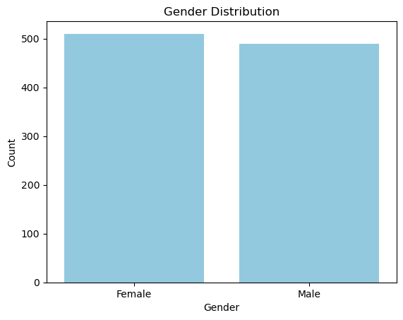

```python
import seaborn as sns
import matplotlib.pyplot as plt
import numpy as np

sns.barplot(x = rsales['Gender'].value_counts().index, y= rsales['Gender'].value_counts(), color="skyblue")

plt.xlabel('Gender')
plt.ylabel('Count')
plt.title('Gender Distribution')
plt.show()
```

[figure not shown]

```python
import seaborn as sns
import matplotlib.pyplot as plt
import numpy as np

sns.barplot(x = rsales['Customer ID'].value_counts().index, y= rsales['Customer ID'].value_counts(), color="skyblue")

plt.xlabel('Customer ID')
plt.ylabel('Count')
plt.title('Customer ID Distribution')
plt.show()
```

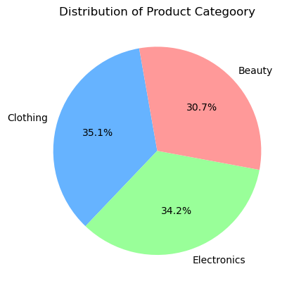

```python
plt.pie(
     rsales['Product Category'].value_counts(),
    labels =rsales['Product Category'].value_counts().index,
    colors=['#66b3ff', '#99ff99', '#ff9999'],
    autopct='%1.1f%%',
    startangle=100
)
plt.title("Distribution of Product Categoory")
plt.show()
```

```python
##numerical data
```

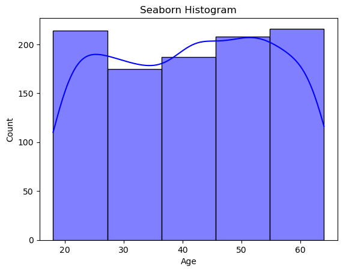

```python
sns.histplot(rsales['Age'], bins=5,kde=True,color='blue')
plt.title('Seaborn Histogram')
plt.show()
```

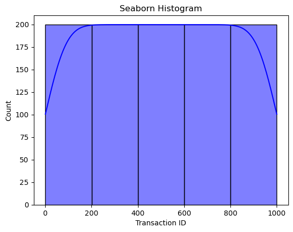

```python
sns.histplot(rsales['Transaction ID'], bins=5,kde=True,color='blue')
plt.title('Seaborn Histogram')
plt.show()
```

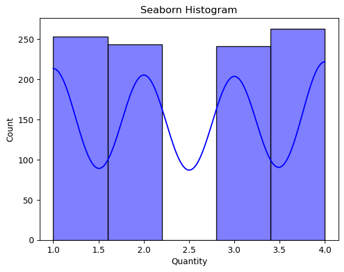

```python
sns.histplot(rsales['Quantity'], bins=5,kde=True,color='blue')
plt.title('Seaborn Histogram')
plt.show()
```

```python
#### checking for outliers using the box plot
```

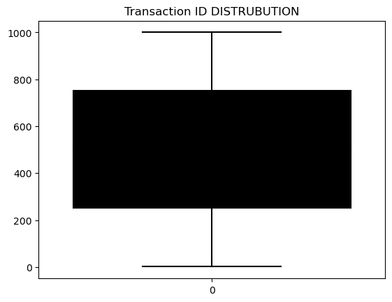

```python
sns.boxplot(data=rsales['Transaction ID'], color='black')
plt.title('Transaction ID DISTRUBUTION')
plt.show()
###no outlier detected
```

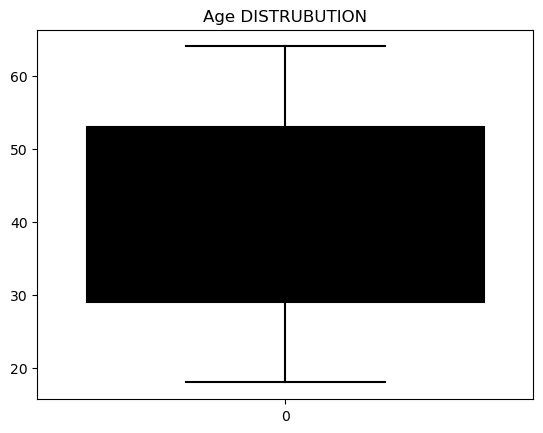

```python
sns.boxplot(data=rsales['Age'], color='black')
plt.title('Age DISTRUBUTION')
plt.show()
###no outlier detected
```

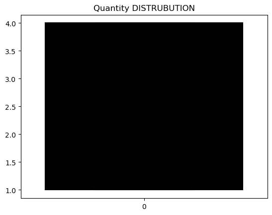

```python
sns.boxplot(data=rsales['Quantity'], color='black')
plt.title('Quantity DISTRUBUTION')
plt.show()
###no outlier detected
```

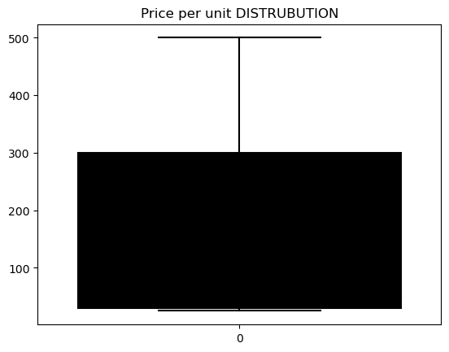

```python
    sns.boxplot(data=rsales['Price per Unit'], color='black')
plt.title('Price per unit DISTRUBUTION')
plt.show()
###no outlier detected
```

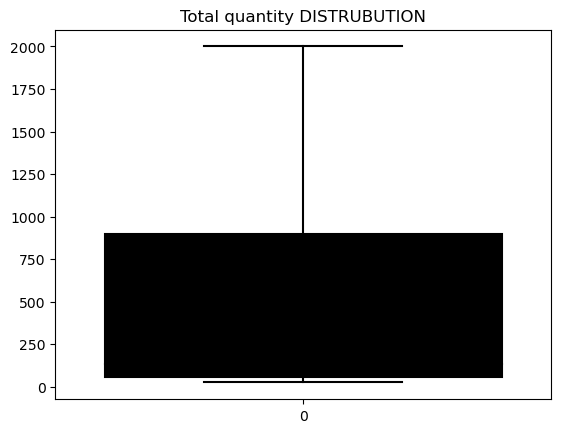

```python
sns.boxplot(data=rsales['Total Amount'], color='black')
plt.title('Total quantity DISTRUBUTION')
plt.show()
###no outlier detected
```

```python
##bivarient analysis
```

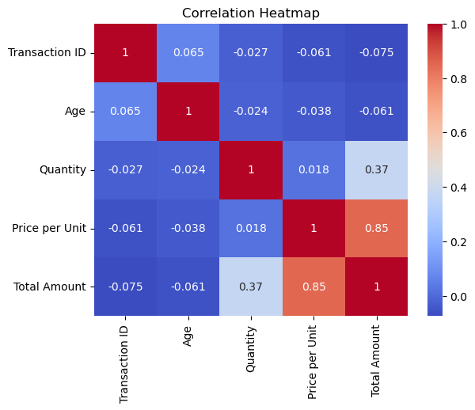

```python
sns.heatmap(rsales.select_dtypes(include=np.number).corr(), annot=True, cmap="coolwarm")
plt.title("Correlation Heatmap")
plt.show()
```